# t 檢定

Week 09｜Part 1・單一樣本、獨立樣本與配對

HT3001B 生物統計學與 R

2026-11-05

## 複習｜假設檢定的六個步驟

| 步驟 | 要做什麼？ |
| --- | --- |
| 1. 形成假設 | 用母體參數寫出虛無假設（null hypothesis）$H_0$ 與對立假設（alternative hypothesis）$H_1$，事先定好方向與顯著水準（significance level）$\alpha$。 |
| 2. 選定統計量 | 依研究設計、資料與適用條件選方法。 |
| 3. 計算統計量 | 把樣本數值代入公式。 |
| 4. 查參考分布 | 在 $H_0$ 成立的條件下，求 $p$ 值（p-value）或臨界值（critical value）。 |
| 5. 做統計決策 | 若 $p\le\alpha$，拒絕 $H_0$。否則，未能拒絕 $H_0$。 |
| 6. 寫研究結論 | 回答原問題，交代差的方向、大小與推論範圍。 |

[IMS 2e §11.3（假設檢定）](https://openintro-ims.netlify.app/foundations-randomization)。本講次整理為六步。

## 複習｜母體標準差已知時的 z 檢定

64 人的平均量表分數是 23 分。已知母體標準差 $\sigma=6$ 分，想知道母體平均是否與基準 25 分不同。

- 設 $H_0:\mu=25$、$H_1:\mu\ne25$，採雙尾檢定（two-tailed test），$\alpha=.01$。
- 在獨立常態抽樣下，$H_0$ 成立時，單一樣本 z 檢定（one-sample z test）的統計量服從標準常態分布（standard normal distribution）。

$$\mathrm{SE}=\frac{\sigma}{\sqrt{n}}=\frac{6}{\sqrt{64}}=0.75,\qquad z=\frac{\bar{x}-\mu_0}{\mathrm{SE}}=\frac{23-25}{0.75}\approx -2.67$$

雙尾 $p\approx .0077<.01$，拒絕 $H_0$。資料支持母體平均異於 25 分，樣本平均比基準低 2 分。

**如果 $\sigma$ 未知，要怎麼估計分母的標準誤（standard error）？**

Rosner 8e §7.4, pp. 222–224（已知母體變異數的雙尾檢定）。量表分數為課堂例題。

## 今天會學哪三種 t 檢定？

剛才用母體標準差 $\sigma$ 算標準誤。當 $\sigma$ 未知，改用樣本估計，並依資料結構決定要比較哪個平均。

| t 檢定 | 跟誰比？ | 今天的例子 |
| --- | --- | --- |
| 單一樣本 t 檢定（one-sample t test） | 一組平均和固定基準比 | 大鼠迷宮 |
| 獨立樣本 t 檢定（independent-samples t test） | 兩組不同個體的平均相比 | 網路搜尋組與非搜尋組 |
| 配對 t 檢定（paired t test） | 先算每對的差，再比較平均差與 0 | 同一人觀看影片前後的分數 |

獨立樣本案例會示範**假定兩組母體變異數相等的合併法（pooled two-sample t test）**。

[IMS 2e Ch. 19–21（平均數推論）](https://openintro-ims.netlify.app/statistical-inference)。等變異數雙樣本 t 檢定見 Rosner 8e §8.4。

## 比較一組樣本的平均數和特定基準值

單一樣本 t 檢定比較樣本平均 $\bar x$ 與假設的母體平均 $\mu_0$。先看能不能直接算出平均數的標準誤。

| 母體標準差 | 用哪個標準誤？ | 參考分布 |
| --- | --- | --- |
| $\sigma$ 已知 | $\sigma/\sqrt n$ | 標準常態分布 |
| $\sigma$ 未知 | 用樣本標準差（sample standard deviation）$s$ 估計，得到 $s/\sqrt n$ | Student t 分布（Student’s t distribution） |

在獨立常態抽樣下，上表的參考分布精確成立。

[IMS 2e §19.2.1–19.2.3（平均數標準誤與 t 分布）](https://openintro-ims.netlify.app/inference-one-mean)。

## t 統計量用估計的標準誤

用樣本標準差 $s$ 估計平均數的標準誤，再把觀察到的差標準化。

$$\widehat{SE}(\bar X)=\sqrt{\frac{s^2}{n}}=\frac{s}{\sqrt n},
\qquad
t=\frac{\bar x-\mu_0}{\widehat{SE}(\bar X)}$$

$t$ 表示樣本平均與基準相差幾個**估計標準誤**。單一樣本 t 檢定的自由度（degrees of freedom, $df$）為 $n-1$。

[IMS 2e §19.2.5（單一樣本 t 統計量）](https://openintro-ims.netlify.app/inference-one-mean)。

## 自由度越小，t 分布的尾巴越厚

重複抽樣時，$\bar X$ 和 $s$ 都會變動。使用 $s$ 估計 $\sigma$，會影響標準化後的分布。

- 自由度小時，峰較低、兩尾較厚。
- 自由度增加時，t 分布趨近標準常態。

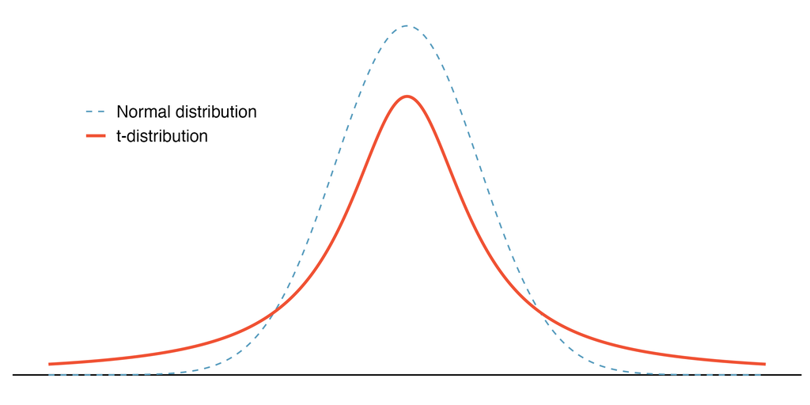

紅色實線是 t 分布。比較兩端，紅線在離中心較遠的地方高於藍色虛線。

[IMS 2e §19.2.3（t 分布與自由度）](https://openintro-ims.netlify.app/inference-one-mean)。課本原圖 19.8（CC BY-SA 3.0）。

## 大鼠迷宮案例｜設定問題與假設

- **研究情境**。研究者想知道，受訓大鼠的 RNA 是否會影響其他大鼠的選路表現。25 隻大鼠接受這些 RNA，之後在 T 型迷宮中反覆選路。
- **怎麼記錄？** 每隻大鼠記一筆資料，也就是牠選到「安全」路徑的總次數。25 隻的平均是 66 次。
- **和什麼比？** 以隨機選路時平均選到安全路徑的 60 次為固定基準，檢驗接受 RNA 的大鼠平均表現是否偏離基準。

$H_0:\mu=60,\qquad H_1:\mu\ne60$，其中 $\mu$ 是接受 RNA 的大鼠在這項任務中的母體平均安全選路次數。

母體標準差未知，使用單一樣本 t 檢定。採雙尾，$\alpha=.05$。

[IMS 2e §19.2.5（單一樣本 t 檢定）](https://openintro-ims.netlify.app/inference-one-mean)。大鼠迷宮為課堂案例。

## 大鼠迷宮案例｜算出 t

每隻大鼠選到安全路徑的次數記為 $x_i$。樣本數 $n=25$，樣本平均 $\bar x=66$，檢定基準 $\mu_0=60$。

**離均差平方和（sum of squares，$SS$）**是把每隻大鼠的次數減去樣本平均 66，各自平方後加總。本例給的摘要是 $SS=\sum_{i=1}^{25}(x_i-66)^2=3259$。

$$\begin{aligned}
s^2 &= \frac{SS}{n-1}=\frac{3259}{24}\approx 135.79\\
\widehat{SE}(\bar X) &= \sqrt{\frac{s^2}{n}}\approx 2.331\\
t &= \frac{66-60}{\widehat{SE}(\bar X)}\approx 2.57
\end{aligned}$$

[IMS 2e §5.4（樣本變異數）](https://openintro-ims.netlify.app/explore-numerical)、[§19.2.5（單一樣本 t 統計量）](https://openintro-ims.netlify.app/inference-one-mean)。大鼠迷宮為課堂案例。

## 大鼠迷宮案例｜查分布、作決策、寫結論

- **查參考分布**。$df=24$，雙尾 $\alpha=.05$，臨界值是 $\pm 2.064$。
- **做統計決策**。$|t|=2.57>2.064$，雙尾 $p\approx .0166$，拒絕 $H_0$。
- **寫研究結論**。接受 RNA 的這組大鼠平均選到安全路徑 66 次，比隨機基準多 6 次。
- **解讀範圍**。本例把一組大鼠與固定基準相比。要判斷差異是否由 RNA 造成，還需要設置條件相同的對照組。

[IMS 2e §19.2.5（單一樣本 t 檢定與結果判讀）](https://openintro-ims.netlify.app/inference-one-mean)。大鼠迷宮為課堂案例。

## 兩組資料有沒有一對一對應？

大鼠案例比較的是一組平均與固定的 60 次。如果另收集一組對照資料，就要先弄清楚兩組觀察是否一一對應。

| 資料設計 | 兩筆觀察怎麼來 | 例子 |
| --- | --- | --- |
| 獨立樣本（independent samples） | 兩組為不同個體，沒有一對一配對 | 一人只在介入或對照其中一組 |
| 配對資料（paired data） | 兩筆量測可連回同一人或預先配成的一對 | 同一人的前測與後測 |

先根據收集資料的方式判斷，再選檢定。

[IMS 2e §21.1（辨認配對資料）](https://openintro-ims.netlify.app/inference-paired-means)。

## 隨機分派如何形成兩個獨立組？

**同一批受試者 → 隨機分派 → 條件一或條件二**

在完全隨機雙組設計（completely randomized two-group design）中，每人只接受一種條件。

- 隨機分派（random assignment）讓基線特徵在重複分派下平均而言平衡。單次實驗仍可能有偶然差異。
- 分派與實驗執行妥當時，兩組結果差異可用來估計處理的因果效果（causal effect）。

[IMS 2e §2.2.1（隨機分派）](https://openintro-ims.netlify.app/data-design)。

## 網路搜尋案例｜設計與資料

**研究問題**。即使讀到相同的解釋，親自上網搜尋的人，會不會更相信自己能回答其他主題的問題？

**研究流程**。例如查高爾夫球表面為何有凹點。兩組用不同方式取得同一篇解釋，接著對氣象、食物等未搜尋主題的答題能力自評（1–7 分）。

| 組別 | 任務 | $n$ | 平均 $\bar x$ | 變異數 $s^2$ |
| --- | --- | --- | --- | --- |
| 網路搜尋 | 上網找到指定網頁 | 93 | 3.78 | 1.42 |
| 非搜尋 | 直接閱讀同一網頁的文字 | 102 | 3.07 | 1.25 |

以下的差固定為**搜尋組 − 非搜尋組**。

[IMS 2e §20.3.1（獨立兩組資料結構）](https://openintro-ims.netlify.app/inference-two-means)。研究來源 [Fisher et al. (2015), Exp. 1c](https://doi.org/10.1037/xge0000070)。

## 網路搜尋案例｜假設與顯著水準

令 $\mu_1$、$\mu_2$ 分別為搜尋組與非搜尋組的母體平均自評分數。

$H_0:\mu_1-\mu_2=0,\qquad H_1:\mu_1-\mu_2\ne0$

課堂示範採雙尾檢定，設定 $\alpha=.001$，每尾分配 .0005。接下來要衡量，兩組平均差在虛無假設下通常會波動多大。

[IMS 2e §20.3（獨立兩組平均差的檢定）](https://openintro-ims.netlify.app/inference-two-means)。顯著水準另見 [IMS 2e §14.1–14.2（顯著水準與雙尾假設）](https://openintro-ims.netlify.app/foundations-errors)。

## 平均差的抽樣分布（sampling distribution）

這次要估計的是**兩組平均差的標準誤**。兩組獨立時，兩個平均數相減的變異數相加。

$$SE(\bar X_1-\bar X_2)=
\sqrt{\frac{\sigma_1^2}{n_1}+\frac{\sigma_2^2}{n_2}}$$

若 $\sigma_1^2=\sigma_2^2=\sigma^2$，就可將根號內的 $\sigma^2$ 提出來。

[figure not shown]

每次重抽兩組會得到一個平均差。虛無假設下，分布中心為 0。

[IMS 2e §20.3.2（平均差的抽樣變異）](https://openintro-ims.netlify.app/inference-two-means)。依該節的抽樣模型重繪。

## 等變異數時，如何合併估計標準誤？

共同母體變異數未知時，用合併變異數（pooled variance）$s_p^2$ 估計。權重是各組的自由度。

$$s_p^2=\frac{(n_1-1)s_1^2+(n_2-1)s_2^2}{(n_1-1)+(n_2-1)}$$

$$\widehat{SE}(\bar X_1-\bar X_2)=\sqrt{s_p^2\left(\frac1{n_1}+\frac1{n_2}\right)}$$

Rosner 8e §8.4, pp. 286–289（合併變異數與平均差的標準誤）。

## 等變異數雙樣本 t 統計量

若兩組獨立、母體常態且有共同變異數，可用等變異數雙樣本 t 檢定（pooled two-sample t test）。

$$t=\frac{\bar x_1-\bar x_2}{\sqrt{s_p^2(1/n_1+1/n_2)}},
\qquad df=(n_1-1)+(n_2-1)$$

虛無假設為母體平均差等於 0。

Rosner 8e §8.4, pp. 286–289（等變異數雙樣本 t 統計量與自由度）。

## 等變異數雙樣本 t 檢定的條件

- 結果為可解讀平均數的數值變項。例如等距尺度（interval scale）或等比尺度（ratio scale）的測量結果。
- 觀察在組內及組間彼此獨立。
- 兩組母體呈常態時，參考分布有精確理論依據。偏態及離群值在小樣本時尤其重要。
- 合併變異數法假定兩組母體變異數相等。兩組樣本數接近只能改善某些情況下的穩健性。

Rosner 8e §8.4, pp. 286–289（等變異數雙樣本 t 檢定的條件）。

## 網路搜尋案例｜用合併標準誤計算 t

假定兩組母體變異數相等。自由度為 $df=(93-1)+(102-1)=193$。

$$\begin{aligned}
s_p^2 &= \frac{92(1.42)+101(1.25)}{193}\approx 1.3310\\
\widehat{SE} &= \sqrt{s_p^2(1/93+1/102)}\approx .1654\\
t &= \frac{3.78-3.07}{\widehat{SE}}\approx 4.29
\end{aligned}$$

Rosner 8e §8.4, pp. 286–289（合併法）。本頁依課堂表列摘要重算。

## 網路搜尋案例｜作決策並解讀差異

- **統計決策**。$df=193$，雙尾 $\alpha=.001$ 的臨界值為 $\pm 3.3416$。以課堂表列摘要重算，$|t|\approx4.29>3.3416$，$p<.001$，拒絕 $H_0$。
- **研究結論**。搜尋組對未搜尋主題的答題能力自評為 3.78 分，非搜尋組為 3.07 分，差 0.71 分。這個結果的測量指標是自評分數。

Fisher 等人的原論文報告 $t(193)=4.30$，與本頁用課堂表列摘要重算所得的 $t\approx4.29$ 得到相同檢定決策。

Rosner 8e §8.4, pp. 286–289（雙尾檢定）。研究來源 [Fisher et al. (2015), Exp. 1c](https://doi.org/10.1037/xge0000070)。

## 網路搜尋案例｜平均差有多大？

檢定提供平均差是否偏離 0 的證據。效果量（effect size）則回答差多少，這裡以合併標準差 $s_p$ 為單位。

**Cohen’s $d$** 是兩組平均差除以合併標準差。搜尋組減非搜尋組，得 $d=(3.78-3.07)/s_p\approx0.615$。

**Hedges’ $g$** 是將 $d$ 乘上校正因子 $J$ 的標準化平均差。這個校正用來減少小樣本的估計偏差。

$$g=Jd,\qquad J\approx 1-\frac{3}{4df-1},\qquad df=n_1+n_2-2$$

本例 $df=193$，$g\approx0.613$。兩組自評相差約 **0.6 個合併標準差**，原量表差 0.71 分。

[Lakens, Ch. 6（§6.4–6.5，標準化平均差與偏差校正）](https://lakens.github.io/statistical_inferences/06-effectsize.html)、[Lakens (2013), 式 (4)](https://doi.org/10.3389/fpsyg.2013.00863)。本頁依課堂表列摘要重算。

## 自然形成的兩組可以比較什麼？

網路搜尋案例由研究者安排兩種任務。若組別是生醫系與生科系這類既有特徵，則屬於自然組比較（natural group comparison）。

若觀察獨立且模型條件適當，可用獨立樣本 t 檢定比較平均。

**這類比較支持描述組間差異。因果解釋需要能處理混雜的研究設計或假設。**

[IMS 2e §2.3（觀察研究與因果解讀）](https://openintro-ims.netlify.app/data-design)。

## 配對 t 是對每對的差做單一樣本 t

剛才每人只屬於一組。如果同一人提供前測與後測，兩筆分數要先配成一對。

| 配對方式 | 一對包含什麼？ |
| --- | --- |
| 重複量數設計（repeated measures design） | 同一人的兩筆量測，例如前測與後測 |
| 預先配對 | 按研究設計配好的一對個體，各提供一筆量測 |

每對先算一個差值，再沿用單一樣本 t 的做法，把這一組差值的平均與 0 相比。各對之間須獨立，常態條件看的是**差值的分布**。

[IMS 2e §21.3.1–21.3.2（配對差與適用條件）](https://openintro-ims.netlify.app/inference-paired-means)。

## 影片案例｜同一人的前測與後測

**研究問題**。大學生看完《The Silent Scream》後，對墮胎的態度分數是否改變？

**研究流程**。同一批 20 位學生在看片前與看片後立即各填一次態度量表。依本例的計分方向，分數越高，代表反對墮胎的態度越強。

**前測 → 觀看影片 → 立即後測**

每人的兩筆分數連成一對，接著算出一筆差值，方向固定為**前測 − 後測**。

[IMS 2e §21.3.1（配對資料與差值）](https://openintro-ims.netlify.app/inference-paired-means)。影片案例資料標示為 Devoe (1990)。

## 影片案例｜先在每一列相減

定義個人差異分數（difference score）$D_i=X_{\text{前},i}-X_{\text{後},i}$。

| 受試者 | 前測 | 後測 | 差值 $D_i$ |
| --- | --- | --- | --- |
| 第 1 人 | 74 | 85 | −11 |

20 人的平均差 $\bar D=56.25-63.85=-7.60$，差值的樣本變異數為 94.78。負號代表後測較高。

[IMS 2e §21.3.1（差值的計算方向）](https://openintro-ims.netlify.app/inference-paired-means)。影片案例資料標示為 Devoe (1990)。

## 影片案例｜假設與顯著水準

令 $\mu_D$ 為母體中「前測 − 後測」的平均差。

$H_0:\mu_D=0,\qquad H_1:\mu_D\ne0$

兩個方向的變化都關心，因此採雙尾檢定，事先設定 $\alpha=.05$。

[IMS 2e §21.3.2（配對平均差的假設）](https://openintro-ims.netlify.app/inference-paired-means)。

## 配對 t 統計量與自由度

$n$ 是完整配對數，$s_D$ 是個人差值的樣本標準差。若虛無假設指定平均差 $\mu_{D,0}=0$：

$$t=\frac{\bar D-\mu_{D,0}}{s_D/\sqrt n}=\frac{\bar D}{s_D/\sqrt n},
\qquad df=n-1$$

影片案例有 20 對，所以 $df=19$。

[IMS 2e §21.3.3（配對 t 統計量）](https://openintro-ims.netlify.app/inference-paired-means)。

## 影片案例｜用 20 個差值算出 t

樣本平均差是 $\bar D=-7.60$，差值的樣本變異數是 $s_D^2\approx94.78$。

$$\widehat{SE}(\bar D)=\sqrt{s_D^2/20}\approx 2.177,
\qquad
t=\frac{-7.60}{\widehat{SE}(\bar D)}\approx -3.49$$

分母估計的是**平均差值**的標準誤。

[IMS 2e §21.3.3（用差值計算配對 t）](https://openintro-ims.netlify.app/inference-paired-means)。影片案例資料標示為 Devoe (1990)。

## 影片案例｜作決策並解讀前後差異

- **統計決策**。$df=19$，雙尾 $\alpha=.05$ 的臨界值為 $\pm 2.093$。$|t|=3.49>2.093$，$p\approx .00244$，拒絕 $H_0$。
- **研究結論**。後測平均高於前測 7.60 分。依本案例的量表方向，分數上升表示後測的反墮胎態度較強。

單組前後測能描述短期變化。要將變化歸因於影片，還要排除其他同時發生的影響。

[IMS 2e §21.3.3（配對 t 的決策與解讀）](https://openintro-ims.netlify.app/inference-paired-means)。影片案例資料標示為 Devoe (1990)。

## 影片案例｜用差值的標準差報效果量

後測平均高了 7.60 分。要把這個變化轉成標準化效果量，分母改用個人差值的樣本標準差 $s_D$。

$$d_z=\frac{\bar D}{s_D}\approx\frac{-7.60}{9.74}=-.78$$

- 有方向的標準化平均差為 $-.78$，對應「前測 − 後測」。
- 只報大小時，$|d_z|\approx .78$。
- 獨立組用組內的合併標準差，配對資料則用**個人差值的標準差**。

[Lakens, Ch. 6（配對效果量 d_z）](https://lakens.github.io/statistical_inferences/06-effectsize.html)。

## 整合練習｜怎麼選 t 檢定？

先辨認比較對象：固定基準、兩組不同個體，還是同一人的兩次量測？再為下列三題選擇 t 檢定。

1. 這班的平均測驗分數和既定基準 70 分有差嗎？
2. 兩組不同學生使用兩種教材，平均分數有差嗎？
3. 同一批學生在課程前後的平均分數改變了嗎？
1. 單一樣本 t。
2. 獨立樣本 t。
3. 配對 t，先算每位學生的前後差。

自編整合練習。課本對照 [IMS 2e Ch. 19–21（平均數推論）](https://openintro-ims.netlify.app/statistical-inference)。

## Student t 分布

t 分布以 0 為中心，左右對稱。自由度越小，兩尾越厚。

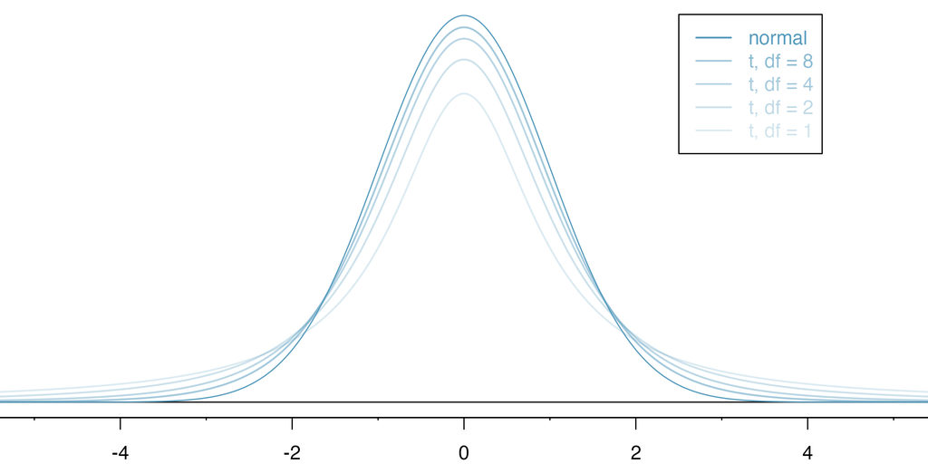

自由度從 1 增至 8 時，t 曲線越接近標準常態。

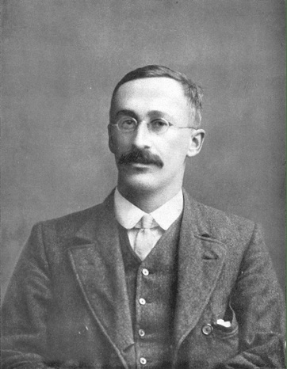

Gosset 以 Student 為筆名。

[IMS 2e §19.2.3（Student t 分布）](https://openintro-ims.netlify.app/inference-one-mean)。課本原圖 19.9（CC BY-SA 3.0）。[Gosset 肖像（IEEE AESS，標為公有領域）](https://ieee-aess.org/post/blog/history-column-william-sealy-gosset-student)。